# PEC

Daniel Rodriguez Fustes

12/1/2022

**Ejercicio 1.**

**Función de Producción de Cobb Douglas**

**La base de datos nativa de R RDPerfComp, que se encuentra en la liberia pder, contiene datos de 509 empresas de USA corresondientes a los años 1982 a 1989, tomados de Blundell, Richard and Stephen Bond (2000) “GMM estimation with persistent panel data: an application to production functions”, Econometric Reviews, 19(3), 321-340.**

**La estructura de la base de datos es la siguiente:**

**– id: identificador de la empresa**

**– year: año**

**– y: producción en logaritmo**

**– n: Empleo en logaritmo**

**– k: Capital en logaritmo**

**• Realice un histograma de la variable y, y estime un modelo GLM para la producción utilizando diferentes familias y links acordes con el histograma. Lógicamente, habrá familias que no se adecuen a estos datos, exponga cuales de estas familias y funciones de ligadura no deben de utilizarse e indique el porqué.**

Se realiza un histograma de la variable “y”:

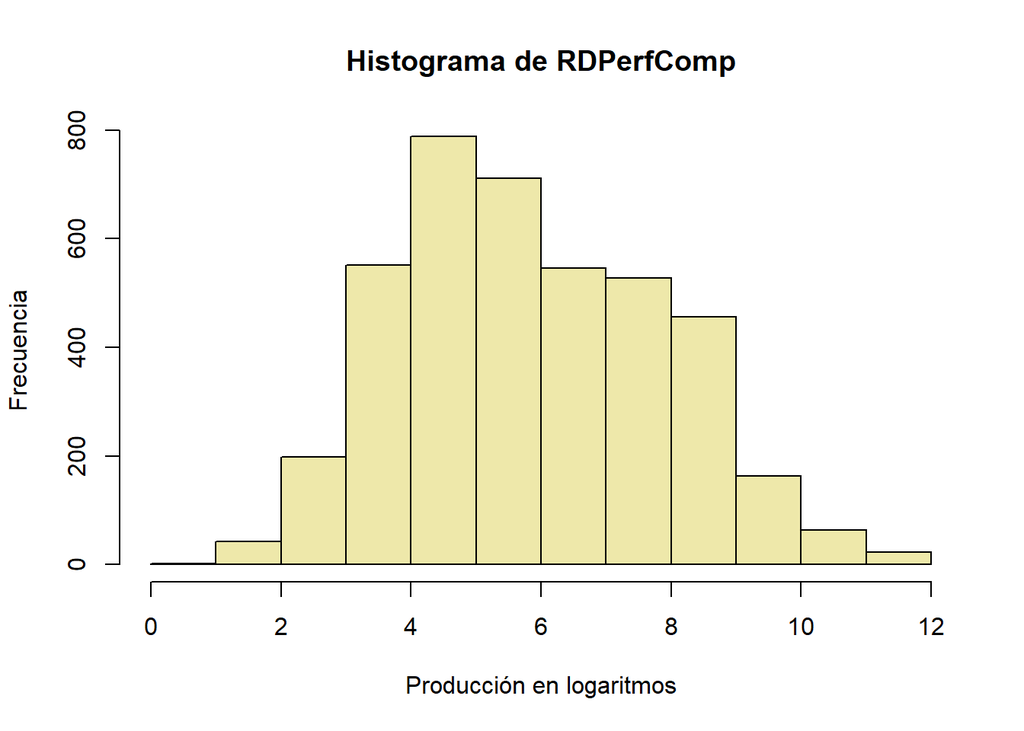

Se observa en el histograma que la distribución de los datos se aproxima a una normal.

En este caso, al tratarse de una regresión sobre variables continuas, no son adecuadas las familias poisson (útil cuando la variable es un número entero, por ejemlo, en conteos), ni tampoco la familia binomial (útil cuando la variable dependiente es de tipo factor), tampoco la familia gamma (adecuada cuando la varianza crece de manera no lineal con respecto a la media).

Las funciones vínculo identidad resultan las más adecuadas en este caso. Ya que las recíprocas (aquel en que la variable explicativa aparece en su forma inversa) tienen sentido únicamente cuando la variable dependiente tiene límites asintóticos (lo cual no ocurre en este caso).

Se decide estimar un modelo GLM para la producción usando la familia gaussiana con función vínculo identidad:

```
##
## Call:  glm(formula = y ~ n + k, family = gaussian(identity), data = datos)
##
## Coefficients:
## (Intercept)            n            k
##      3.0051       0.5606       0.4299
##
## Degrees of Freedom: 4071 Total (i.e. Null);  4069 Residual
## Null Deviance:       16450
## Residual Deviance: 508.4     AIC: 3091
```

**• Realice lo mismo, pero con los datos en niveles.**

Se transforman los datos en logaritmos a nivelves usando la función exp():

Se prueba ahora un modelo GLM para la producción con función vínculo identidad con distribución de errores gamma (datos en niveles):

```
##
## Call:  glm(formula = y ~ n + k, family = Gamma(identity), data = datos.niv)
##
## Coefficients:
## (Intercept)            n            k
##      1.5256      66.9480       0.7426
##
## Degrees of Freedom: 4071 Total (i.e. Null);  4069 Residual
## Null Deviance:       16200
## Residual Deviance: 501.4     AIC: 50780
```

**• Comente los resultados de las regresiones que ha realizado y compare la bondad del ajuste de ambos modelos.**

El primer modelo estimado con datos en logaritmos tanto en la variable dependiente como en las independientes es de tipo log-log o modelo de elasticidad constante. Estos modelos son adecuados cuando se tiene interés en corregir la posible heterocedasticidad, además, la interpretación de los parámetros es porcentual. Esto es, un cambio de un 1% en una de las variables independientes se traduce en un cambio porcentual sobre la variable dependiente por valor del parámetro estimado asociado a dicha variable independiente. Así pues, en el primer modelo estimado la interpretación es:

- Por cada 1% que aumenta la variable de empleo, la variable producción aumenta en 0.56%.
- Por cada 1% que aumenta la variable de capital, la variable producción aumenta en 0.43%.

El segundo modelo estimado con datos en niveles es una regresión lineal estándar con una distribución de los errores de tipo gamma. En este modelo un cambio en una unidad en una de las variables explicativas se traduce en un cambio sobre la variable dependiente igual al valor del parámetro estimado asociado a dicha variable. Por tanto:

- Por cada unidad que aumenta la variable de empleo, la variable producción aumenta en 66 unidades.
- Por cada unidad que aumenta la variable de capital, la variable producción aumenta en 0.74 unidades.

Comparando los AIC se observa que el primer modelo obtiene 3091 y el segundo modelo 50781, siendo mucho menor, y por tanto preferible, el primer modelo.

El modelo en logaritmos obtiene un ajuste más adecuado, posiblemente debido a que las variables en logaritmos corrigen la heterocedasticidad.

**• Presente el sumario de resultados y el gráfico de XY con los puntos reales y los datos estimados, especificando en el título la función estimada.**

Sumario de resultados de la estimación del modelo $y_t=\beta_0 +\beta_1 n_t + \beta_2 k_t + e_t$ con los datos en logaritmos:

```
##
## Call:
## glm(formula = y ~ n + k, family = gaussian(identity), data = datos)
##
## Deviance Residuals:
##      Min        1Q    Median        3Q       Max
## -1.27994  -0.21733  -0.02985   0.19612   1.59486
##
## Coefficients:
##             Estimate Std. Error t value Pr(>|t|)
## (Intercept) 3.005052   0.029310  102.53   <2e-16 ***
## n           0.560581   0.009641   58.15   <2e-16 ***
## k           0.429859   0.007952   54.05   <2e-16 ***
## ---
## Signif. codes:  0 '***' 0.001 '**' 0.01 '*' 0.05 '.' 0.1 ' ' 1
##
## (Dispersion parameter for gaussian family taken to be 0.124935)
##
##     Null deviance: 16451.29  on 4071  degrees of freedom
## Residual deviance:   508.36  on 4069  degrees of freedom
## AIC: 3091.2
##
## Number of Fisher Scoring iterations: 2
```

Gráfico de la estimación del modelo $y_t=\beta_0 +\beta_1 n_t + \beta_2 k_t + e_t$ :

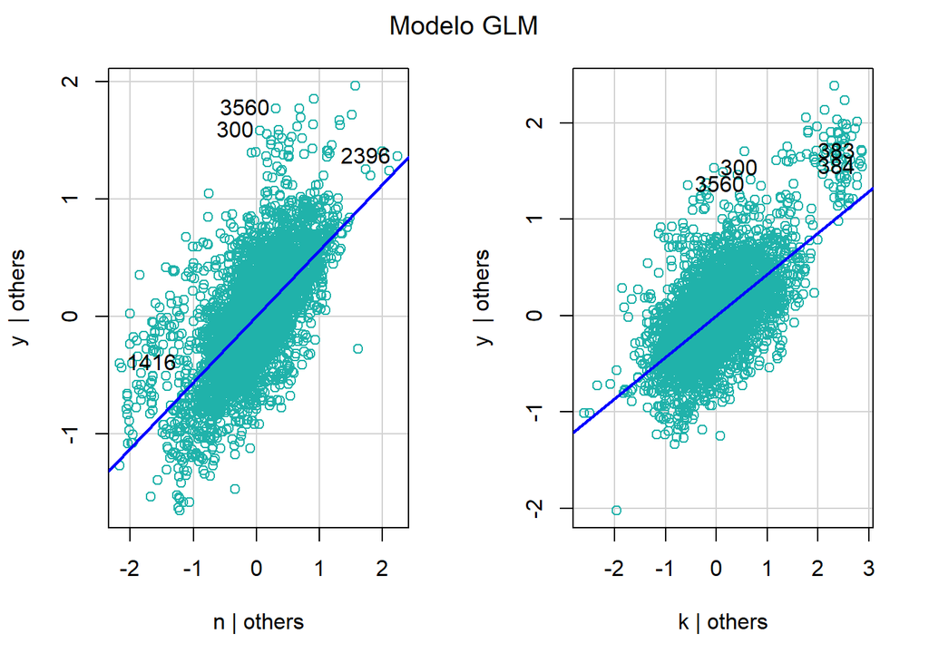

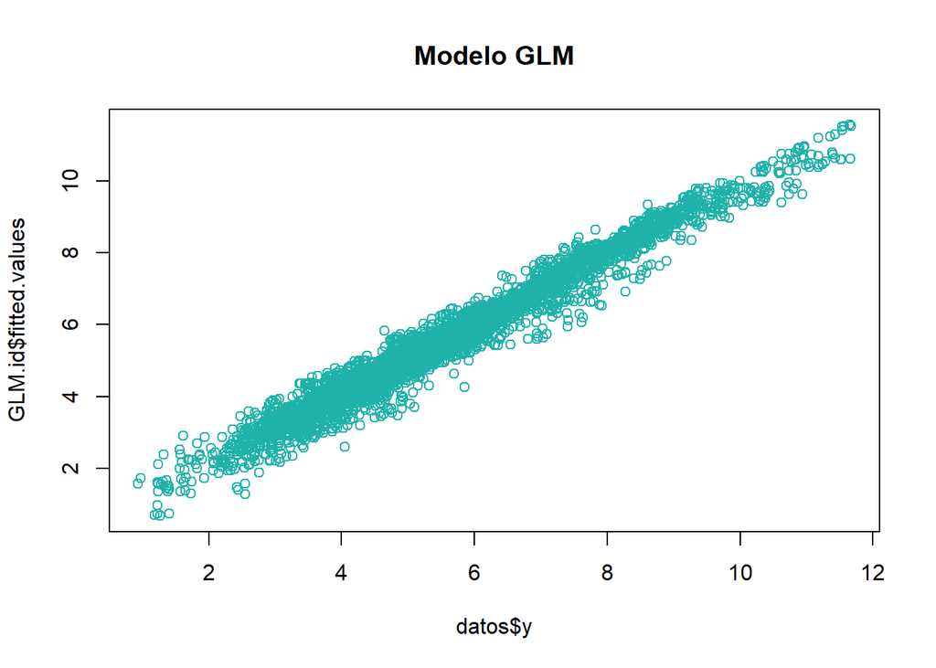

**• Realice un pronóstico de y correspondiente a una empresa con 30 empleados. En el pronóstico presente los intervalos de confianza al 95% y 90%. Presente el pronóstico en niveles de producción.**

Se considera la media para el capital.

La media del capital (en logaritmos) es 5.01

El nivel de producción esperado es 1172

Los intervalos de confianza al 95% son [1123 , 1222]

Los intervalos de confianza al 90% son [1131 , 1214]

**Ejercicio 2**

**Diseño experimental**

**Un investigador se propone estudiar el desarrollo de la aptitud en análisis de datos de un determinado grupo de estudiantes. A tal propósito, confecciona una serie de tareas estandarizadas, consistentes en el desarrollo de cuatro modelos de análisis. Estas tareas son presentadas a los estudiantes, cuando realizan las evaluaciones. Las evaluaciones son programadas de forma secuencial a lo largo del curso.**

**Por último, el rendimiento en la resolución de los modelos es valorado con una escala de 10 puntos. Dado que el investigador considera de interés estudiar la posible diferencia atribuible al género, elige dos muestras iguales de escolares de uno y otro género. Los resultados se muestran en el fichero Notas.xlsx.**

**• ¿Qué tipo de modelo es el más adecuado para este análisis? Realice un dibujo representando dicho modelo.**

Se dedice especificar un modelo con variable dependiente “Calificacion” y como variable explicativa “Sexo”. La variable dependiente es de tipo cuantitativo. Se procede a establecer la clase de la variable explicativa “Sexo” como factor. Se decide suprimir del estudio las variables “Prueba” y”Sujeto” puesto que se considera que no pueden aportar valor al estudio.

El modelo elegido será de tipo ANOVA $Y_i=\beta_0 +\mu_1 D_1 + u_i$

Se muestra un dibujo donde se representan en diagramas de caja las distribuciones de las dos variables objeto de estudio:

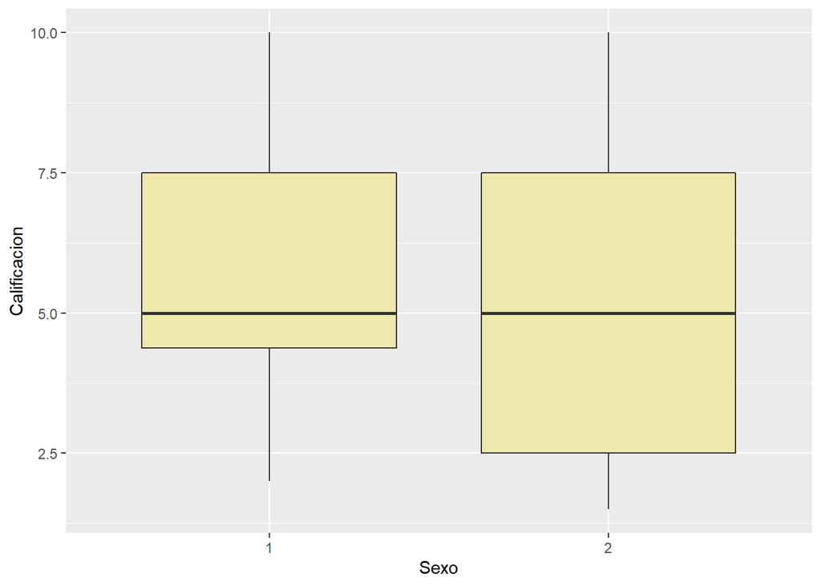

Se puede observar que ambas distribuciones son muy similares, con una mediana prácticamente igual. El tercer cuartil también tiene el mismo valor en ambas variables. También se puede observar que la varianza es similar para los dos conjuntos de datos, lo cual es importante, ya que se cumple la hipótesis de homocedasticidad, que es necesaria para poder realizar un modelo de análisis de la varianza. Los valores mínimos y máximos también son similares.

**• Haga un análisis descriptivo de los datos teniendo en cuenta los factores definidos.**

En primer lugar se realiza el test de Levene para contrastar la hipótesis nula de homocedasticidad de la varianza:

|  | Df | F value | Pr(>F) |
| --- | --- | --- | --- |
| group | 1 | 0.1664556 | 0.685571 |

El p-valor del estadístico es superior a 0.05 por lo que no se puede rechazar la hipótesis nula de homocedasticidad de la varianza.

En segundo lugar se presenta la frecuencia de los datos y se realiza el test de Saphiro para contrastar la hipótesis nula de normalidad:

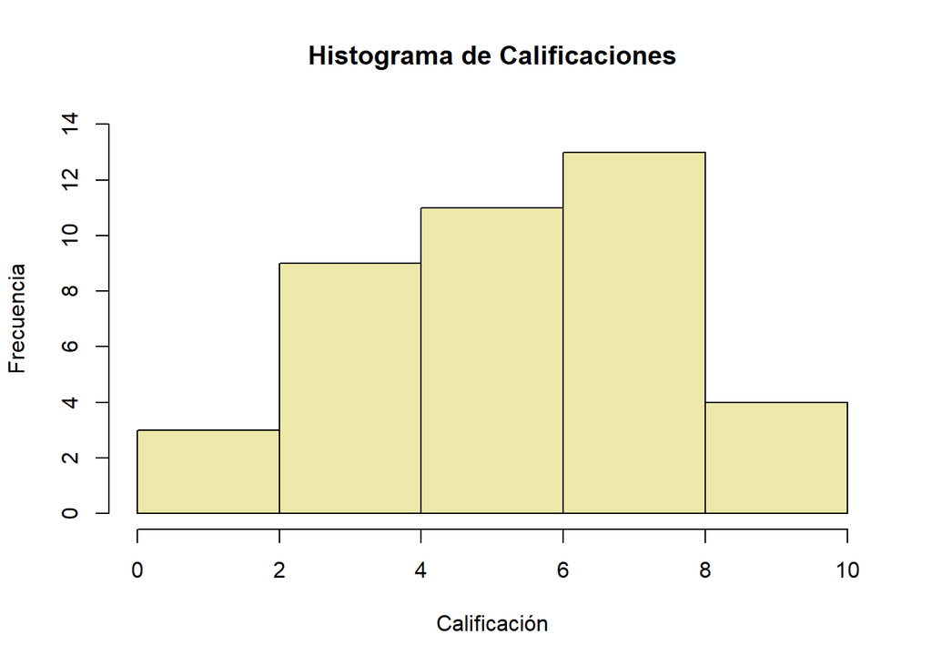

Visualmente se aproxima a una normal, aunque los datos de “Calificaciones” son claramente discretos.

Tests de normalidad de Saphiro por cada valor que toma el factor “Sexo”:

| statistic | p.value | method |
| --- | --- | --- |
| 0.8977254 | 0.0373896 | Shapiro-Wilk normality test |

| statistic | p.value | method |
| --- | --- | --- |
| 0.875103 | 0.0144615 | Shapiro-Wilk normality test |

Los test de Saphiro han resultado con p-valores inferiores a 0.05 por lo que se rechaza la hipótesis nula de normalidad. Pero, como se sabe que la media se encuentra en 5.5125 y la mediana es 5 y viendo el histograma, se considera la normalidad en la distribución.

En tercer lugar, se van a comparar las medias mediante el test de Tukey:

```
##
##   Simultaneous Tests for General Linear Hypotheses
##
## Multiple Comparisons of Means: Tukey Contrasts
##
##
## Fit: aov(formula = Calificacion ~ Sexo, data = notas)
##
## Linear Hypotheses:
##            Estimate Std. Error t value Pr(>|t|)
## 2 - 1 == 0  -0.6250     0.8165  -0.765    0.449
## (Adjusted p values reported -- single-step method)
```

Por tanto, no se puede rechazar la hipótesis nula de medias iguales entre los dos sexos.

**• Estime el modelo anteriormente planteado, comente los resultados obtenidos y establezca las conclusiones pertinentes derivadas de este estudio.**

Se muestra el resultado de la estimación del modelo $Y_i=\beta_0 +\mu_1 D_1 + u_i$

```
##             Df Sum Sq Mean Sq F value Pr(>F)
## Sexo         1   3.91   3.906   0.586  0.449
## Residuals   38 253.34   6.667
```

La variable “Sexo” ha resultado ser no significativa, ya que el p-valor es superior a 0.05

La media de calificación global de los datos es 5.5125

La media de calificación del sexo 1 es 5.825

La media de calificación del sexo 2 es 5.2

Conclusión: la variable explicativa “Sexo” no resulta significativa ni siquiera al 90%. Además, los tests descriptivos realizados apuntan a que no hay diferencias entre las medias de ambos sexos en relación con las calificaciones obtenidas, por lo que la conclusión es que la variable sexo no es un factor diferencial de las calificaciones obtenidas por los estudidantes.

**3. Análisis factorial y Análisis Cluster**

**En el fichero de calidad_vida.csv figuran los datos de 2017 por Comunidades Autónomas relativos a la DIMENSIÓN 1. CONDICIONES MATERIALES DE VIDA, de los indicadores de calidad de vida que publica el Institituto Nacional de Estadística.**

**Los Subdominios e Indicadores parciales de la Dimensión 1 son los siguientes:**

**1.1. Condiciones económicas**

**1.1.1. Renta media y mediana**

**1.1.2. Población en riesgo de pobreza relativa según distintos umbrales**

**1.1.4. Desigualdad (S80/S20)**

**1.1.5. Satisfacción con la situación económica del hogar**

**1.2. Condiciones materiales**

**1.2.1. Dificultades para llegar a fin de mes**

**1.2.2. Carencia material**

**1.2.3. Población que vive en hogares con determinadas deficiencias en la Vivienda**

**1.2.4. Población con falta de espacio en la vivienda**

**1.2.5. Población con gasto elevado en vivienda**

**1.2.6. Satisfacción con la vivienda**

**1.3. Seguridad económica**

**1.3.2. Incapacidad de hacer frente a gastos económicos imprevistos**

**1.3.3. Retrasos en los pagos**

**• Lea el fichero, y realice las pruebas pertinentes para ver si el conjunto de datos puede ser objeto de análisis factorial. De ser cierto, plantee una análisis factorial con la libreria “psych”, respondiendo que criterio ha elegido para seleccionar los factores y que porcentaje de varianza explican los factores elegidos. Interprete el significado de dichos factores.**

Una vez cargados los datos se observa que solamente se disponen de 19 observaciones para un total de 13 variables. Si se intenta estimar un modelo econométrico sin reducir la dimensionalidad se tendrá un problema en relación con los grados de libertad y los resultados no serán fiables.

Por este motivo, tiene sentido intentar agrupar las variables que están correlacionadas entre sí y crear un factor por cada grupo de variables correlacionadas. Los factores que se generen estarán incorrelacionados.

En primer lugar, para averiguar si es posible realizar un análisis factorial se comprueba si existe multicolinealidad aproximada entre todas las variables numéricas. Se genera un gráfico con la matriz de correlaciones:

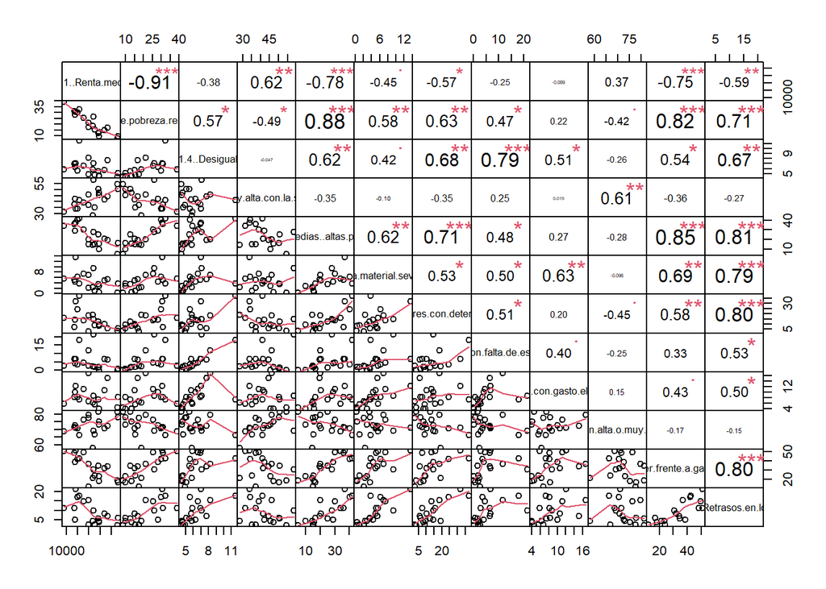

Se observa que existe una alta correlación entre muchas de las variables, por lo que el conjunto de datos parece adecuado para estudiar mediante el análisis factorial.

Tras la inspección visual del gráfico de correlaciones se crea la matriz de correlaciones y se procede a realizar el test de Bartlett.

El test de Bartlett brinda un p-valor de 1.4738333^{-16} que es inferior a 0.05 por lo que el estadístico es significativo, es decir, se rechaza la hipótesis nula y por lo tanto la matriz de correlaciones no es una matriz identidad lo que implica que su determinante es aproximadamente cero, lo cual nos indica que las variables están correlacionadas y pueden ser objeto de un análisis factorial.

Se calcula el test Kaiser-Meyer-Olkin para evaluar lo adecuado que es el conjunto de datos para realizar el análisis factorial.

El resultado del KMO es 0.596607 que es un valor mediocre pero suficiente para realizar el análisis factorial.

Se procede a realizar el análisis factorial para extraer los factores.

En primer lugar, se procura averiguar el número de factores que se deben crear, para ello se realiza el gráfico de sedimientación para elegir el número óptimo de factores según los autovalores:

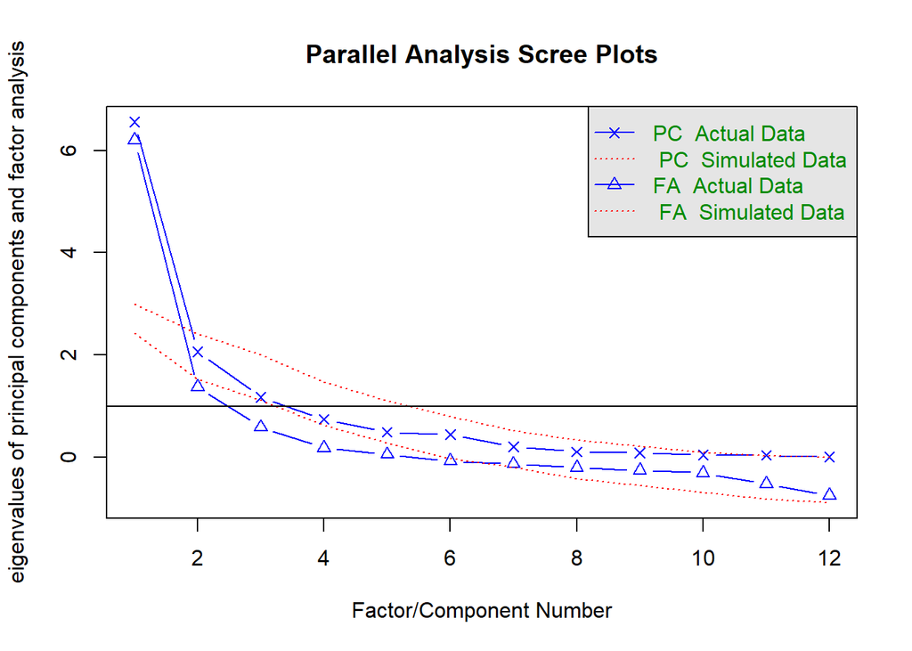

```
## Parallel analysis suggests that the number of factors =  1  and the number of components =  1
```

El resultado del análisis paralelo nos sugiere establecer el número de factores en uno. El gráfico de sedimientación nos sugiere extraer 2 o 3 factores. Puesto que solamente se disponen de 19 observaciones,se decide establecer el número de factores extraídos en dos.

Se realiza el análisis factorial de máxima verosimilitud sin rotación para comprobar el porcentaje de la varianza que explican los factores extraídos.

```
##
## Call:
## factanal(x = calidad[, 2:13], factors = 2, scores = "Bartlett",     rotation = "none")
##
## Uniquenesses:
##                                                              X1.1.1..Renta.mediana
##                                                                              0.060
##           X1.1.2..Población.en.riesgo.de.pobreza.relativa.según.distintos.umbrales
##                                                                              0.060
##                                                                X1.1.4..Desigualdad
##                                                                              0.419
##          X1.1.5..Satisfacción.alta.o.muy.alta.con.la.situación.económica.del.hogar
##                                                                              0.541
##                        X1.2.1..Dificultades.medias..altas.para.llegar.a.fin.de.mes
##                                                                              0.136
##                                       X1.2.2..Carencia.material.severa.SENTIDO....
##                                                                              0.357
## X1.2.3..Población.que.vive.en.hogares.con.determinadas.deficiencias.en.la.vivienda
##                                                                              0.408
##                              X1.2.4..Población.con.falta.de.espacio.en.la.vivienda
##                                                                              0.545
##                                    X1.2.5..Población.con.gasto.elevado.en.vivienda
##                                                                              0.576
##                               X1.2.6..Satisfacción.alta.o.muy.alta.con.la.vivienda
##                                                                              0.805
##                X1.3.2..Incapacidad.de.hacer.frente.a.gastos.económicos.imprevistos
##                                                                              0.211
##                                                      X1.3.3..Retrasos.en.los.pagos
##                                                                              0.130
##
## Loadings:
##                                                                                    Factor1
## X1.1.1..Renta.mediana                                                              -0.910
## X1.1.2..Población.en.riesgo.de.pobreza.relativa.según.distintos.umbrales            0.964
## X1.1.4..Desigualdad                                                                 0.604
## X1.1.5..Satisfacción.alta.o.muy.alta.con.la.situación.económica.del.hogar          -0.499
## X1.2.1..Dificultades.medias..altas.para.llegar.a.fin.de.mes                         0.920
## X1.2.2..Carencia.material.severa.SENTIDO....                                        0.653
## X1.2.3..Población.que.vive.en.hogares.con.determinadas.deficiencias.en.la.vivienda  0.718
## X1.2.4..Población.con.falta.de.espacio.en.la.vivienda                               0.465
```

[output cut: 11 more lines]

```
## X1.2.3..Población.que.vive.en.hogares.con.determinadas.deficiencias.en.la.vivienda  0.277
## X1.2.4..Población.con.falta.de.espacio.en.la.vivienda                               0.489
## X1.2.5..Población.con.gasto.elevado.en.vivienda                                     0.580
## X1.2.6..Satisfacción.alta.o.muy.alta.con.la.vivienda                                0.240
## X1.3.2..Incapacidad.de.hacer.frente.a.gastos.económicos.imprevistos                 0.160
## X1.3.3..Retrasos.en.los.pagos                                                       0.462
##
##                Factor1 Factor2
## SS loadings      6.020   1.731
## Proportion Var   0.502   0.144
## Cumulative Var   0.502   0.646
##
## Test of the hypothesis that 2 factors are sufficient.
## The chi square statistic is 67.69 on 43 degrees of freedom.
## The p-value is 0.00952
```

Se observa que el factor 1 explica el 50,2% de la varianza común y el factor 2 explica el 14,4% de la varianza común. Los dos factores explican de forma conjunta el 64,6% de la varianza común.

Las variables más representadas en cada factor son:

- Factor 1:
  - X1.1.1..Renta.mediana
  - X1.1.2..Población.en.riesgo.de.pobreza.relativa.según.distintos.umbrales
  - X1.1.4..Desigualdad
  - X1.1.5..Satisfacción.alta.o.muy.alta.con.la.situación.económica.del.hogar
  - X1.2.1..Dificultades.medias..altas.para.llegar.a.fin.de.mes
  - X1.2.2..Carencia.material.severa.SENTIDO….
  - X1.2.3..Población.que.vive.en.hogares.con.determinadas.deficiencias.en.la.vivienda
  - X1.2.6..Satisfacción.alta.o.muy.alta.con.la.vivienda
  - X1.3.2..Incapacidad.de.hacer.frente.a.gastos.económicos.imprevistos
  - X1.3.3..Retrasos.en.los.pagos
- Factor 2:
  - X1.2.4..Población.con.falta.de.espacio.en.la.vivienda
  - X1.2.5..Población.con.gasto.elevado.en.vivienda

**• Realice el mismo análisis con la librería rela. ¿Son equivalentes los resultados obtenidos? Exponga las diferencias.**

La librería rela permite ejecutar el análisis factorial de eje principal.

En primer lugar, se muestra el gráfico de barras con el número de factores que el eje principal va a extraer (factores con autovalores superior a 1):

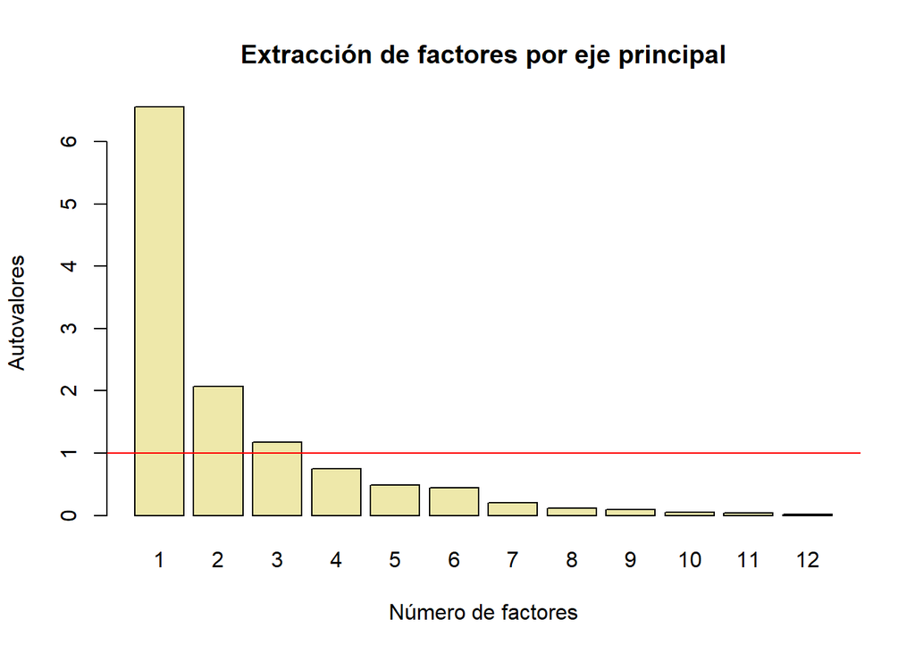

El eje principal extrae 3 factores. A continuación, se muestra la carga factorial.

```
## $loadings
##
## Loadings:
##                                                                                    [,1]
## X1.1.1..Renta.mediana                                                               0.588
## X1.1.2..Población.en.riesgo.de.pobreza.relativa.según.distintos.umbrales           -0.659
## X1.1.4..Desigualdad                                                                -0.424
## X1.1.5..Satisfacción.alta.o.muy.alta.con.la.situación.económica.del.hogar           0.185
## X1.2.1..Dificultades.medias..altas.para.llegar.a.fin.de.mes                        -0.733
## X1.2.2..Carencia.material.severa.SENTIDO....                                       -0.763
## X1.2.3..Población.que.vive.en.hogares.con.determinadas.deficiencias.en.la.vivienda -0.456
## X1.2.4..Población.con.falta.de.espacio.en.la.vivienda                              -0.267
## X1.2.5..Población.con.gasto.elevado.en.vivienda                                    -0.537
## X1.2.6..Satisfacción.alta.o.muy.alta.con.la.vivienda                               -0.122
## X1.3.2..Incapacidad.de.hacer.frente.a.gastos.económicos.imprevistos                -0.868
## X1.3.3..Retrasos.en.los.pagos                                                      -0.819
##                                                                                    [,2]
## X1.1.1..Renta.mediana                                                              -0.683
## X1.1.2..Población.en.riesgo.de.pobreza.relativa.según.distintos.umbrales            0.610
## X1.1.4..Desigualdad                                                                 0.141
## X1.1.5..Satisfacción.alta.o.muy.alta.con.la.situación.económica.del.hogar          -0.778
## X1.2.1..Dificultades.medias..altas.para.llegar.a.fin.de.mes                         0.447
## X1.2.2..Carencia.material.severa.SENTIDO....
## X1.2.3..Población.que.vive.en.hogares.con.determinadas.deficiencias.en.la.vivienda  0.457
## X1.2.4..Población.con.falta.de.espacio.en.la.vivienda
## X1.2.5..Población.con.gasto.elevado.en.vivienda                                    -0.261
## X1.2.6..Satisfacción.alta.o.muy.alta.con.la.vivienda                               -0.736
## X1.3.2..Incapacidad.de.hacer.frente.a.gastos.económicos.imprevistos                 0.320
## X1.3.3..Retrasos.en.los.pagos                                                       0.203
##                                                                                    [,3]
## X1.1.1..Renta.mediana
## X1.1.2..Población.en.riesgo.de.pobreza.relativa.según.distintos.umbrales            0.266
## X1.1.4..Desigualdad                                                                 0.757
## X1.1.5..Satisfacción.alta.o.muy.alta.con.la.situación.económica.del.hogar           0.207
## X1.2.1..Dificultades.medias..altas.para.llegar.a.fin.de.mes                         0.313
## X1.2.2..Carencia.material.severa.SENTIDO....                                        0.300
## X1.2.3..Población.que.vive.en.hogares.con.determinadas.deficiencias.en.la.vivienda  0.501
## X1.2.4..Población.con.falta.de.espacio.en.la.vivienda                               0.910
## X1.2.5..Población.con.gasto.elevado.en.vivienda                                     0.291
## X1.2.6..Satisfacción.alta.o.muy.alta.con.la.vivienda                               -0.295
## X1.3.2..Incapacidad.de.hacer.frente.a.gastos.económicos.imprevistos                 0.135
## X1.3.3..Retrasos.en.los.pagos                                                       0.394
##
##                 [,1]  [,2]  [,3]
## SS loadings    4.121 2.627 2.301
## Proportion Var 0.343 0.219 0.192
## Cumulative Var 0.343 0.562 0.754
##
## $rotmat
##         [,1]     [,2]     [,3]
## [1,] 0.76405 -0.45437 -0.45802
## [2,] 0.17614  0.82987 -0.52942
## [3,] 0.62065  0.32383  0.71409
```

Se observa que el factor 1 explica el 34,3% de la varianza común, el factor 2 explica el 21,9% de la varianza común y el factor 3 explica el 19,2%. Los tres factores explican de forma conjunta el 75,4% de la varianza común.

Las variables más representadas en cada factor son:

- Factor 1:
  - X1.1.2..Población.en.riesgo.de.pobreza.relativa.según.distintos.umbrales
  - X1.2.1..Dificultades.medias..altas.para.llegar.a.fin.de.mes
  - X1.2.2..Carencia.material.severa.SENTIDO….
  - X1.2.5..Población.con.gasto.elevado.en.vivienda
  - X1.3.2..Incapacidad.de.hacer.frente.a.gastos.económicos.imprevistos
  - X1.3.3..Retrasos.en.los.pagos
- Factor 2:
  - X1.1.1..Renta.mediana
  - X1.1.5..Satisfacción.alta.o.muy.alta.con.la.situación.económica.del.hogar
  - X1.2.6..Satisfacción.alta.o.muy.alta.con.la.vivienda
- Factor 3:
  - X1.1.4..Desigualdad
  - X1.2.3..Población.que.vive.en.hogares.con.determinadas.deficiencias.en.la.vivienda
  - X1.2.4..Población.con.falta.de.espacio.en.la.vivienda

**• A la vista de ambos análisis: ¿Agruparía las variables en los subdominios que utiliza el INE?**

Debido a alta correlación entre las variables del conjunto de datos, parece adecuado agrupar por factores las variables que son similares entre sí. Además el tamaño muestral es pequeño, por lo que también resulta beneficioso agrupar variables.

**• Por último, incorpore a la base de datos la/s variable/s nueva/s con las puntuaciones factoriales y realice con ellas un clúster de las CCAA utilizando el método de Ward. Determine el número más adecuado de clústeres, e interprete los resultados.**

Se realiza el cálculo de las puntuaciones asociadas al análisis factorial y se cargan en el análisis clúster. A continuación, se muestra el gráfico del análisis clúster sin agrupar objetos y se muestra la altura sobre la que se realizará el corte:

| Factor1 | Factor2 |
| --- | --- |
| -10335.3 | 3890.6 |
| -14408.0 | 5344.3 |
| -14253.5 | 5309.9 |
| -12676.4 | 4758.2 |
| -10445.3 | 3961.3 |
| -12733.7 | 4724.9 |
| -13635.9 | 5060.6 |
| -10487.6 | 3936.7 |
| -15272.6 | 5685.2 |
| -11832.3 | 4445.5 |
| -8673.7 | 3281.1 |
| -13388.5 | 4975.9 |
| -15697.5 | 5844.2 |
| -10817.3 | 4076.6 |
| -17347.5 | 6414.6 |
| -17496.1 | 6483.1 |
| -14366.0 | 5328.4 |
| -11053.1 | 4185.1 |
| -13443.3 | 5039.8 |

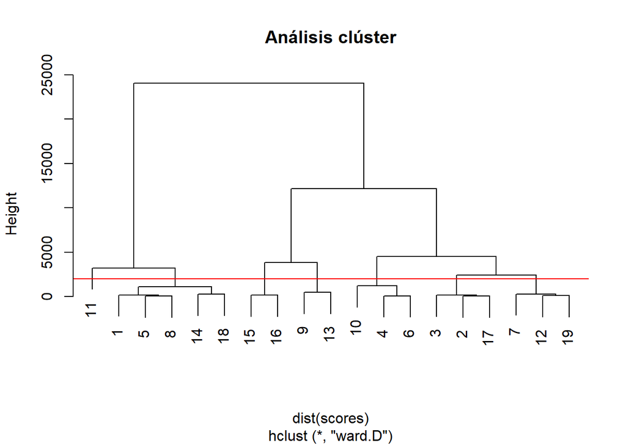

Se muestra el análisis clúster con 7 conglomerados:

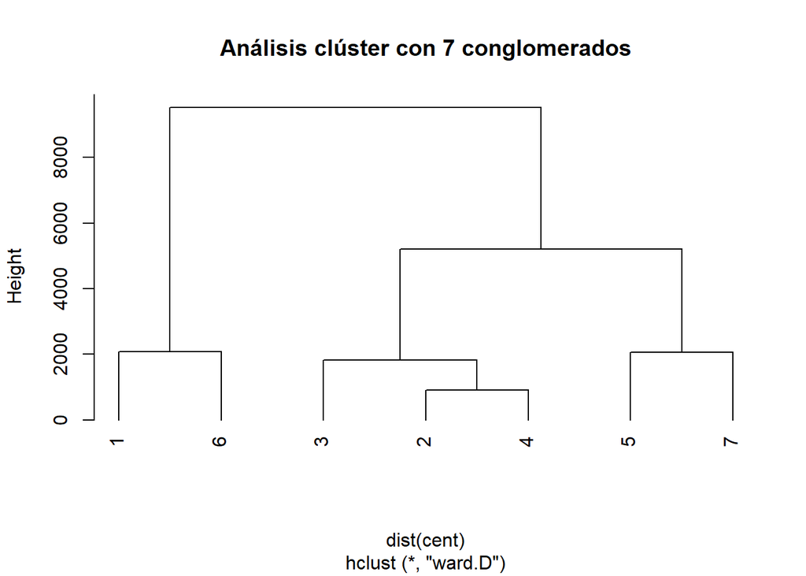

De izquierda a derecha los conglomerados representan:

- El clúster 1 incluye a : Extremadura
- El clúster 6 incluye a : Andalucía, Canarias, Castilla-La Mancha, Murcia y Ceuta
- El clúster 3 incluye a : Navarra y País Vasco
- El clúster 2 incluye a : Cataluña y Madrid
- El clúster 4 incluye a : Valencia, Baleares y Cantabria
- El clúster 5 incluye a : Aragón, Asturias y La Rioja
- El clúster 7 incluye a : Castilla y León, Galicia y Melilla

Cada conglomerado reúne las comunidades autónomas con calidad de vida similar en base a los factores extraídos mediante análisis factorial.

Se deducen tres grandes grupos que de forma muy genérica se podrían establecer en :

- Calidad de vida baja: clústeres 1 y 6
- Calidad de vida media: clústeres 5 y 7
- Calida de vida alta: clústeres 2,3 y 4

**4. Análisis de Correspondencias Múltiple**

**El conjunto de datos de hardware de Hartigan screws.sav contiene información sobre las características de los tornillos, pernos, tuercas y tachuelas.**

**• Analice estos datos a través de un Análisis de Correspondencias Múltiple. Comente los resultados e interprete las dimensiones obtenidas.**

El conjunto de datos contiene 7 variables, de las cuales 6 son de tipo nominal (explican caracteríticas cualitativas) y pueden ser tratadas como factores. La variable “long” es la única que puede ser tratada como variable ordinal. El conjunto de datos solo dispone de 24 observaciones por lo que resulta apropiado realizar un análisis de correspondencias.

Se realiza el análisis de correspondencias múltiple para agrupar los niveles con características similares en nuevas dimensiones cuantitativas.

En primer lugar, se realiza una inspección descriptiva de los datos con el recuento por nivel de factor:

|  | rosca | cabeza | muesca | punta | cobre | long |
| --- | --- | --- | --- | --- | --- | --- |
|  | No_rosca:12 | PLANA : 9 | Estrella: 1 | Plana: 6 | No_Cobre:20 | 1:10 |
|  | Si_rosca:12 | REDONDO:15 | Ninguna :12 | Punta:18 | Si_Cobre: 4 | 2: 6 |
|  | NA | NA | Ranura :11 | NA | NA | 3: 2 |
|  | NA | NA | NA | NA | NA | 4: 4 |
|  | NA | NA | NA | NA | NA | 5: 2 |

Se muestra el sumario en formato gráfico:

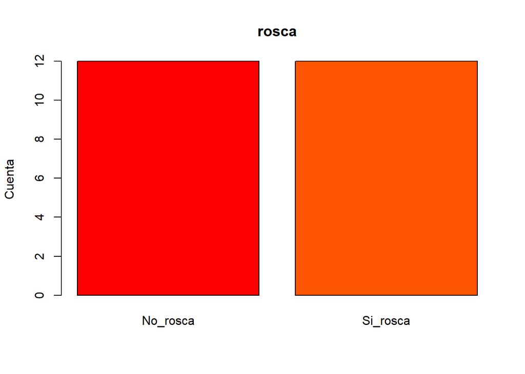

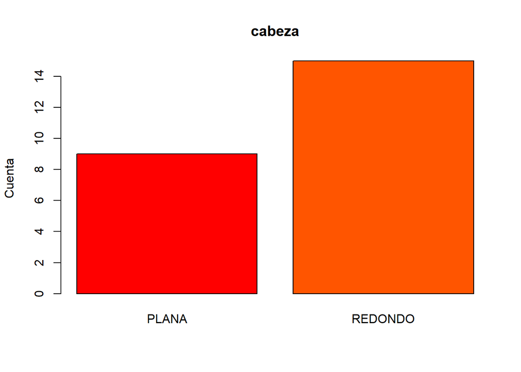

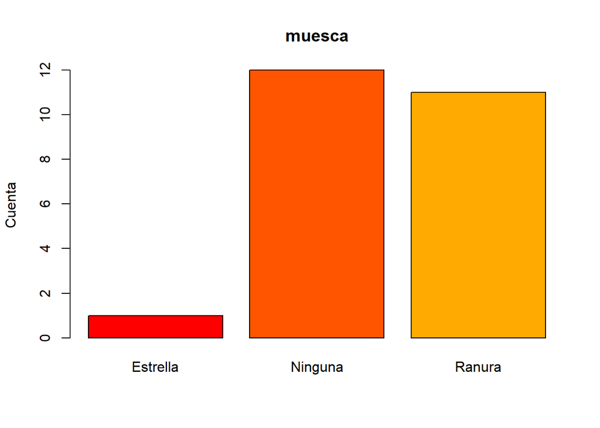

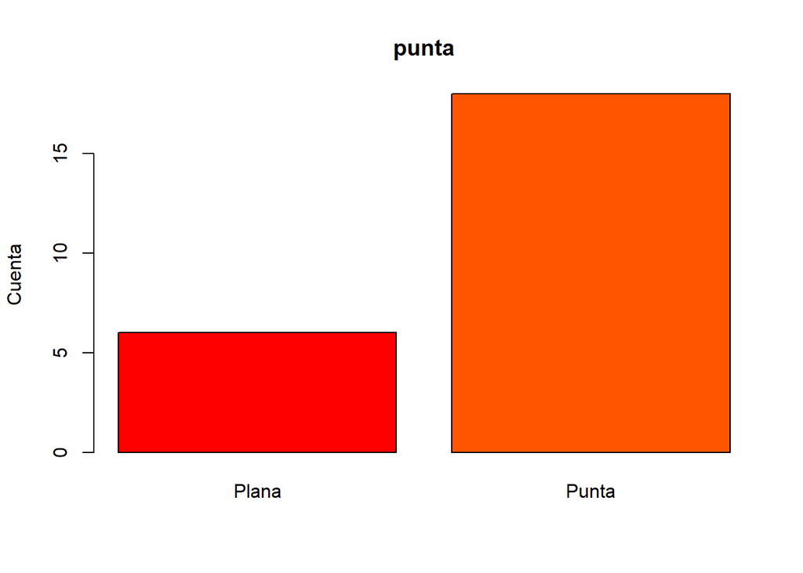

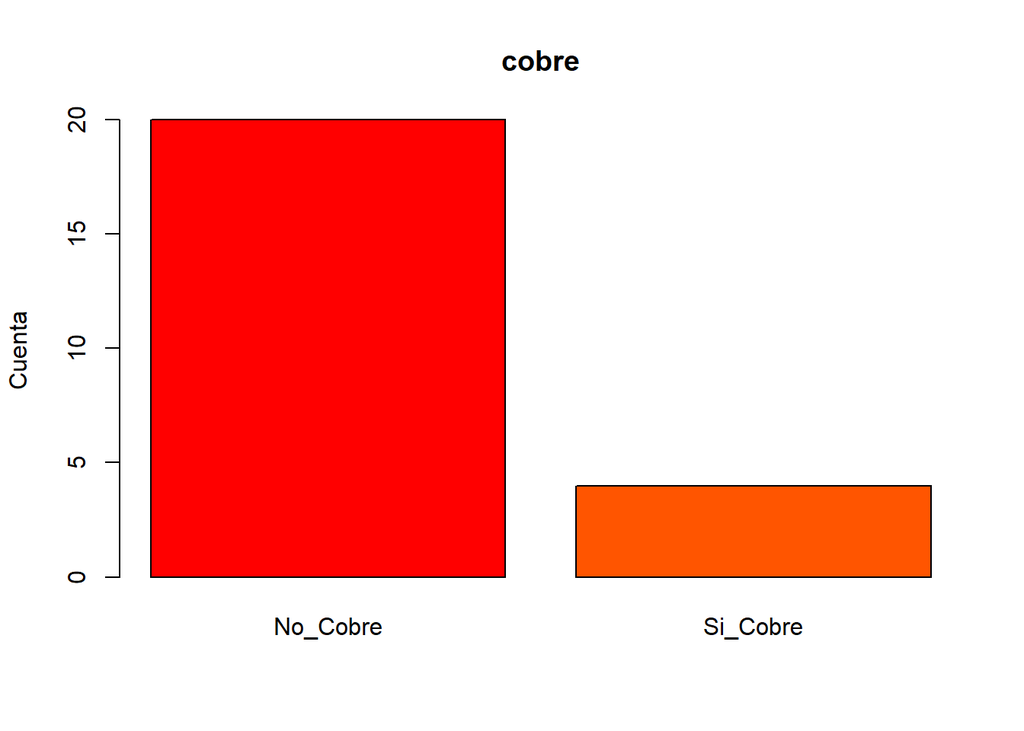

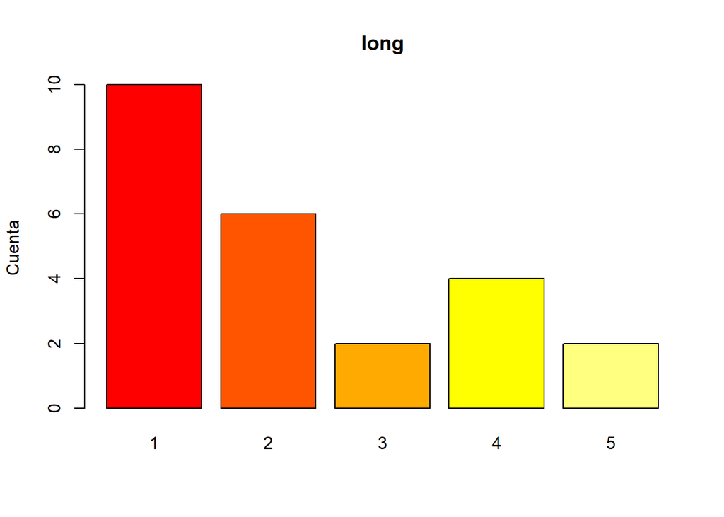

Se estima el modelo y se muestran los autovalores junto a las varianzas retenidas por cada dimensión:

|  | eigenvalue | percentage of variance | cumulative percentage of variance |
| --- | --- | --- | --- |
| dim 1 | 0.56357 | 33.8143 | 33.814 |
| dim 2 | 0.31636 | 18.9813 | 52.796 |
| dim 3 | 0.24533 | 14.7200 | 67.516 |
| dim 4 | 0.19694 | 11.8165 | 79.332 |
| dim 5 | 0.15672 | 9.4030 | 88.735 |
| dim 6 | 0.10845 | 6.5072 | 95.242 |
| dim 7 | 0.05874 | 3.5242 | 98.767 |
| dim 8 | 0.02056 | 1.2335 | 100.000 |
| dim 9 | 0.00000 | 0.0000 | 100.000 |
| dim 10 | 0.00000 | 0.0000 | 100.000 |

El 67,5% de la varianza queda explicada con las tres primeras dimensiones.

Se muestra el gráfico:

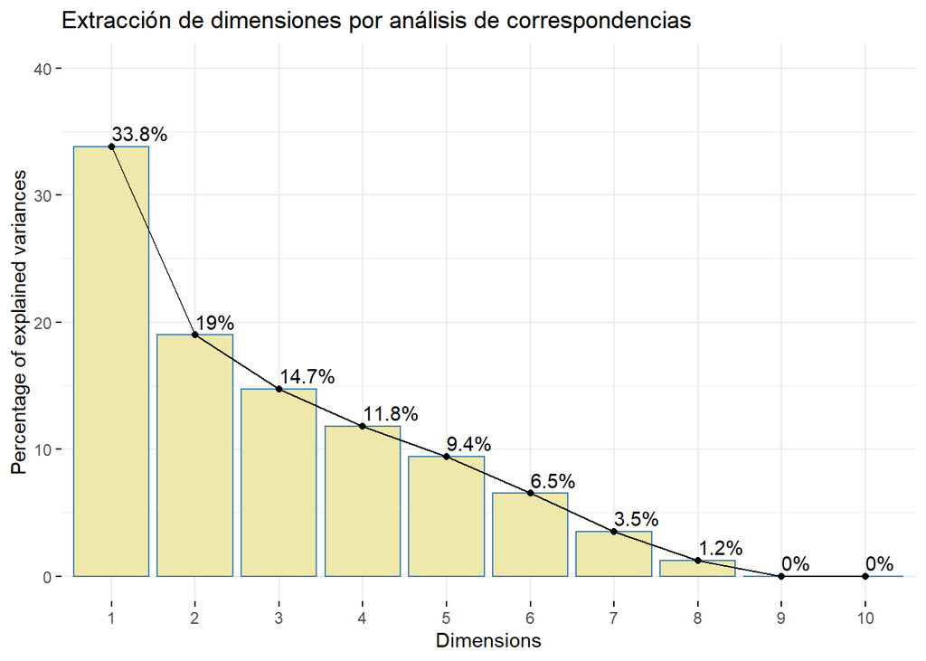

Se realiza la estimación para 3 dimensiones y se muestran las coordenadas por dimensión:

|  | Dim 1 | Dim 2 | Dim 3 |
| --- | --- | --- | --- |
| No_rosca | 0.95431 | -0.01698 | -0.05033 |
| Si_rosca | -0.95431 | 0.01698 | 0.05033 |
| PLANA | 1.08136 | -0.35585 | 0.10477 |
| REDONDO | -0.64881 | 0.21351 | -0.06286 |
| Estrella | -0.59138 | 3.73302 | 2.14074 |
| Ninguna | 0.95431 | -0.01698 | -0.05033 |
| Ranura | -0.98730 | -0.32084 | -0.13971 |
| Plana | -1.27433 | -0.57410 | 0.11327 |
| Punta | 0.42478 | 0.19137 | -0.03776 |
| No_Cobre | -0.14938 | 0.19463 | -0.30158 |
| Si_Cobre | 0.74688 | -0.97313 | 1.50790 |
| 1 | -0.24100 | -0.75042 | 0.78447 |
| 2 | 0.59008 | 0.10689 | -0.82064 |
| 3 | 0.64465 | 0.62968 | -1.06538 |
| 4 | -0.56466 | 0.03275 | -0.87866 |
| 5 | -0.08060 | 2.73626 | 1.36230 |

Las variables más representadas en cada dimensión son:

- Dimensión 1:
  - No_rosca
  - Si_rosca
  - PLANA
  - REDONDO
  - Ninguna
  - Ranura
  - Plana
  - Punta
- Dimensión 2:
  - Estrella
  - Longitud 5
- Dimensión 3:
  - No_Cobre
  - Si_Cobre
  - Longitud 1
  - Longitud 2
  - Longitud 3
  - Longitud 4

Se genera un biplot simétrico.

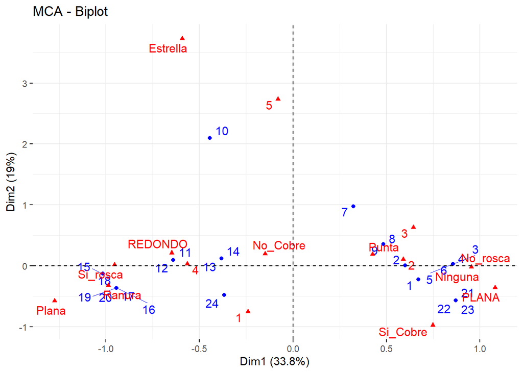

Se presenta graficamente la correlación entre variables y dimensiones principales:

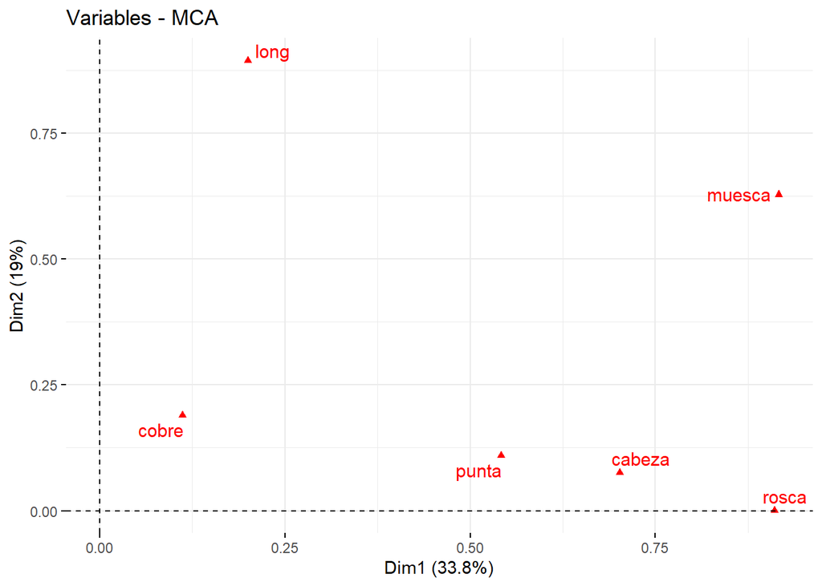

Las variables “rosca”, “cabeza” y “punta” están muy correlacionadas con la dimensión 1 y poco correlacionadas con la dimensión 2.

La variable “muesca” está muy correlacionada con las dimensiones 1 y 2.

La variable “cobre” está poco correlacionada con las dimensiones 1 y 2.

La variable “long” está muy correlacionada con la dimensión 2 y poco correlacionada con la dimensión 1.

Se muestra en un gráfico la calidad en la representación de las categorías de las variables:

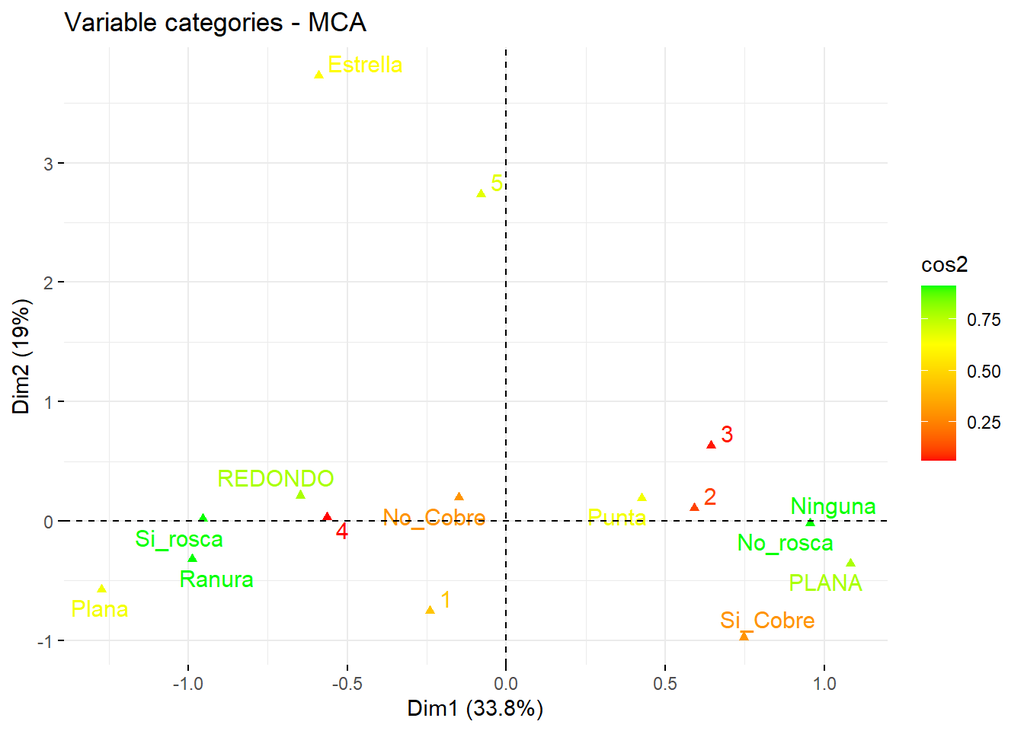

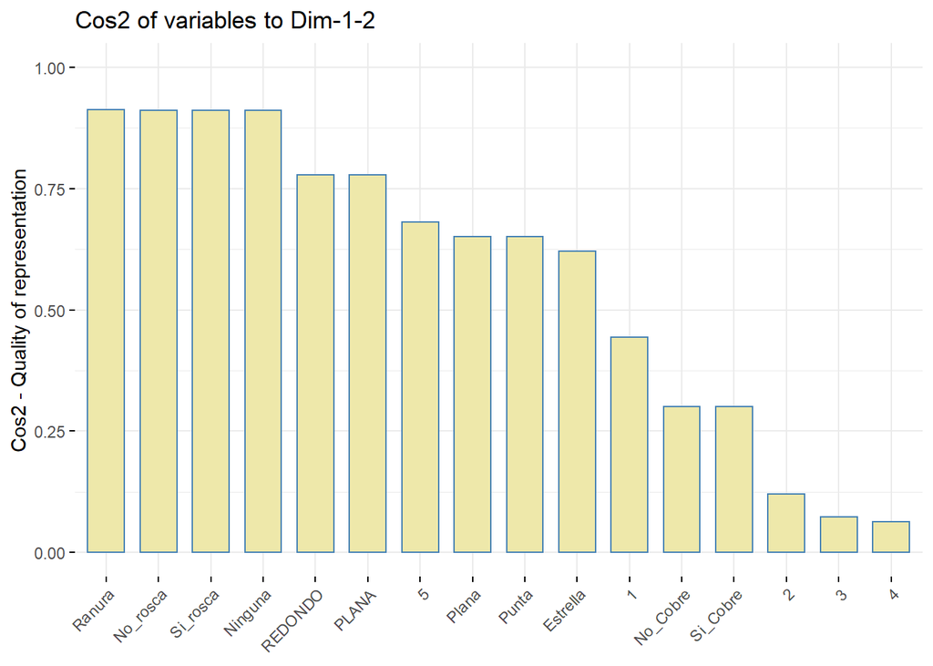

Se muestra las contribuciones de las filas a las dimensiones:

Contribución de las filas a la dimensión 1:

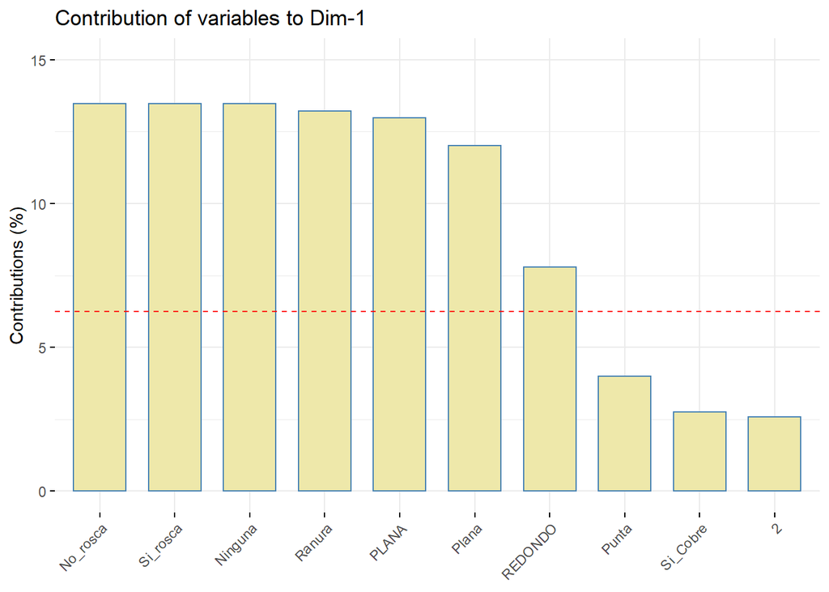

Contribución de las filas a la dimensión 2:

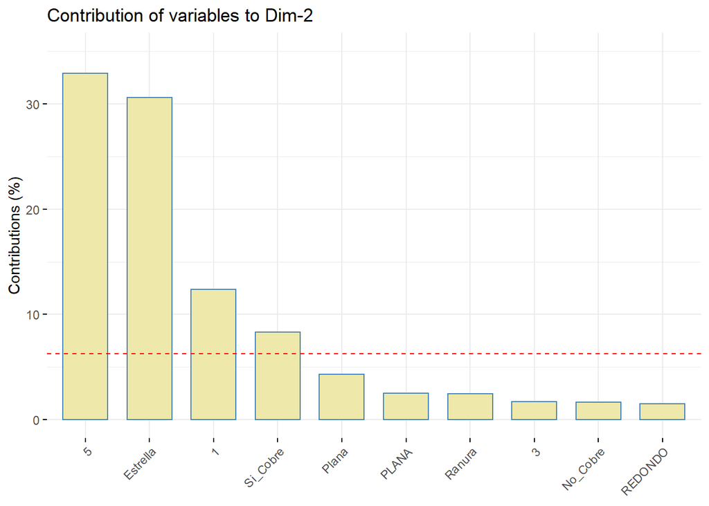

Contribución de las filas a la dimensión 3:

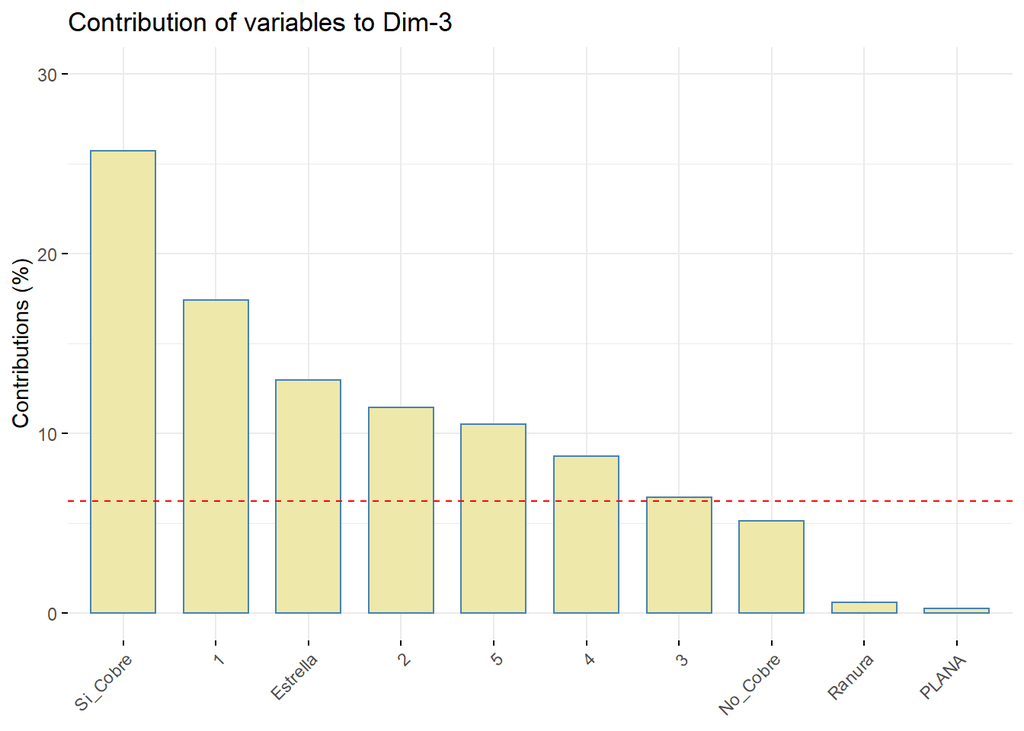

Contribución de las filas a todas las dimensiones:

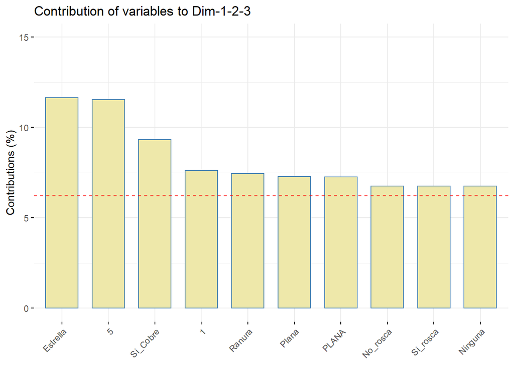

Se realiza el análisis de los objetos.

Se muestran las coordenadas de los primeros objetos:

| Dim 1 | Dim 2 | Dim 3 |
| --- | --- | --- |
| 0.67144 | -0.22350 | 0.15116 |
| 0.59959 | 0.00857 | -0.40846 |
| 0.85595 | 0.03054 | -0.38894 |
| 0.85595 | 0.03054 | -0.38894 |
| 0.85595 | 0.03054 | -0.38894 |
| 0.85595 | 0.03054 | -0.38894 |

| Dim 1 | Dim 2 | Dim 3 |
| --- | --- | --- |
| 3.3332 | 0.65790 | 0.38808 |
| 2.6579 | 0.00097 | 2.83356 |
| 5.4168 | 0.01229 | 2.56917 |
| 5.4168 | 0.01229 | 2.56917 |
| 5.4168 | 0.01229 | 2.56917 |
| 5.4168 | 0.01229 | 2.56917 |

| Dim 1 | Dim 2 | Dim 3 |
| --- | --- | --- |
| 0.48304 | 0.05352 | 0.02448 |
| 0.23446 | 0.00005 | 0.10881 |
| 0.61055 | 0.00078 | 0.12606 |
| 0.61055 | 0.00078 | 0.12606 |
| 0.61055 | 0.00078 | 0.12606 |
| 0.61055 | 0.00078 | 0.12606 |

Se muestra en un gráfico la calidad en la representación de las categorías de los objetos:

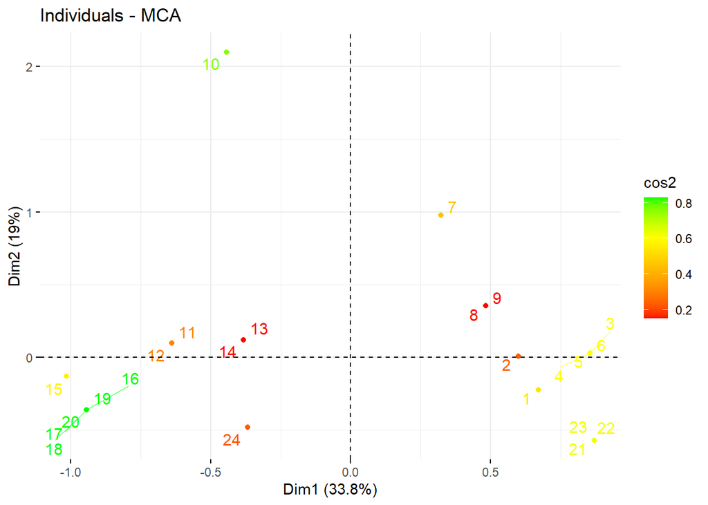

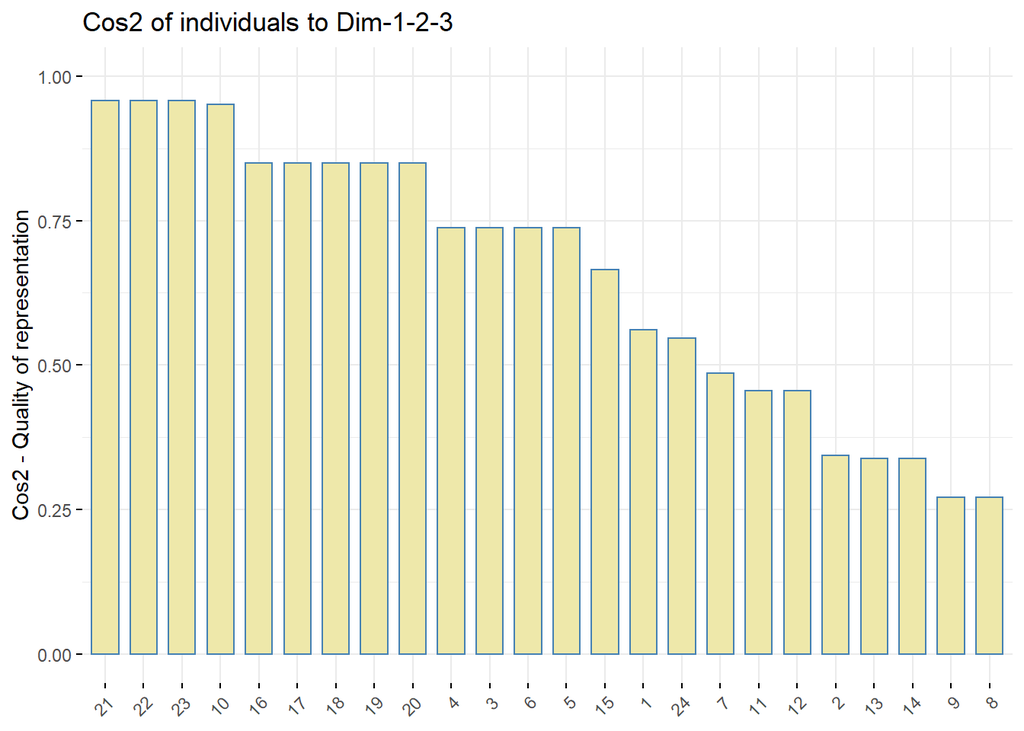

Se muestra las contribuciones de los objetos a las dimensiones:

Contribución de los objetos a las dimensión 1:

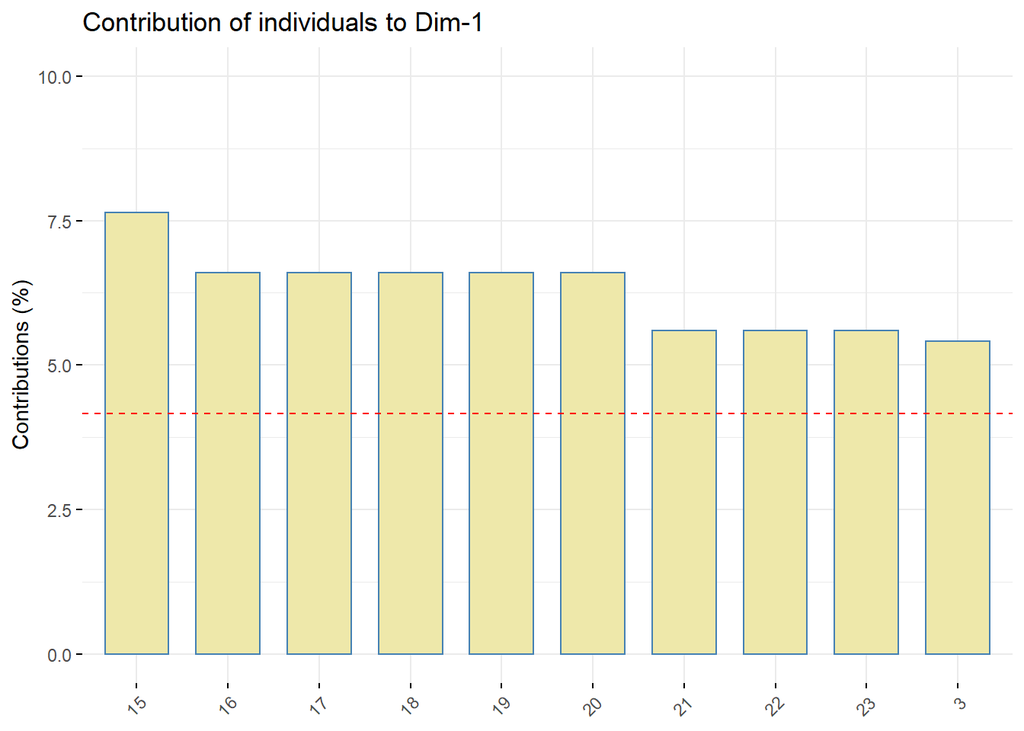

Contribución de los objetos a las dimensión 2:

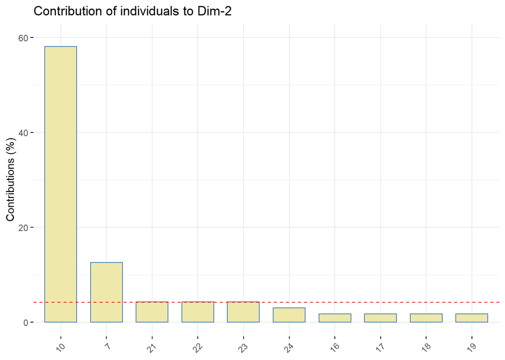

Contribución de los objetos a las dimensión 3:

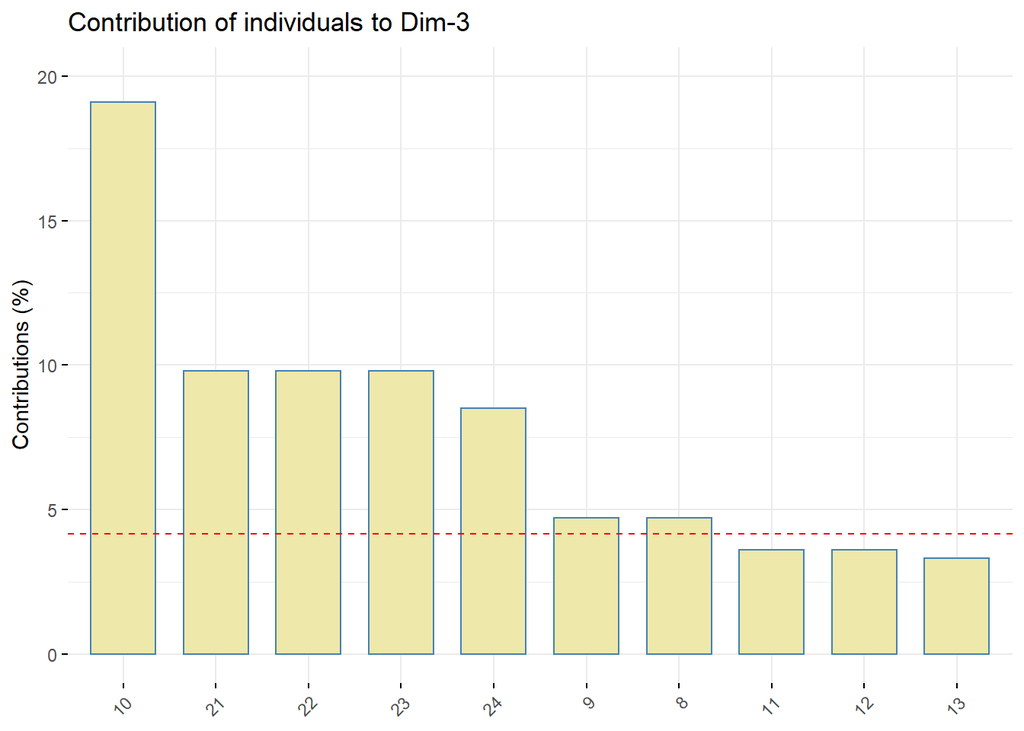